# Comparing Number of DNA FISH Spots Per Nucleus from RFLearner and UNet-2L

Prabhakar R. Gudla

Aug 13, 2017

## Description

Here we will compare the FISH copy number from two biological replicates using RFLeaner and Unet. We will restrict the analysis to wells containing all three probes (Green/Red/FarRed).

```r
datadirs <- c('./ExperimentLevelData/rflearner_based/testp1',
              './ExperimentLevelData/rflearner_based/testp2',
              './ExperimentLevelData/cnn_based/testp1',
              './ExperimentLevelData/cnn_based/testp2')

platenames <- c('Test-P1', 'Test-P2',  'Test-P1', 'Test-P2')

# Function for reading plate's CSV file with FISH copy number, for out wells without all three probes, and renaming n12-11-14 to 12-11-14
readplatecsvandfilter <- function(fname, pname){
  myplate <- fread(fname)
  myplate <- myplate[myplate$`Green Probe Detect` =='X' & myplate$`Red Probe Detect` =='Y' & myplate$`Far Red Probe Detect` =='Z',]
  myplate$Replicate <- pname
  myplate$`probe set`[myplate$`probe set` == "n12-11-14"] <- "12-11-14"
  return (myplate)
}

# Plate TEST-P1-RF
plateid <- 1
plate.71.rf.G <- readplatecsvandfilter(paste0(datadirs[plateid], '/', 'GreenCT_Histogram_PerWell_all.csv'), platenames[plateid])
plate.71.rf.R <- readplatecsvandfilter(paste0(datadirs[plateid], '/', 'RedCT_Histogram_PerWell_all.csv'), platenames[plateid])
plate.71.rf.FR <- readplatecsvandfilter(paste0(datadirs[plateid], '/', 'FarRedCT_Histogram_PerWell_all.csv'), platenames[plateid])

# Plate TEST-P2-RF
plateid <- 2
plate.72.rf.G <- readplatecsvandfilter(paste0(datadirs[plateid], '/', 'GreenCT_Histogram_PerWell_all.csv'), platenames[plateid])
plate.72.rf.R <- readplatecsvandfilter(paste0(datadirs[plateid], '/', 'RedCT_Histogram_PerWell_all.csv'), platenames[plateid])
plate.72.rf.FR <- readplatecsvandfilter(paste0(datadirs[plateid], '/', 'FarRedCT_Histogram_PerWell_all.csv'), platenames[plateid])

# Plate TEST-P2-UNET
plateid <- 3
plate.71.unetfh.G <- readplatecsvandfilter(paste0(datadirs[plateid], '/', 'GreenCT_Histogram_PerWell.csv'), platenames[plateid])
plate.71.unetfh.R <- readplatecsvandfilter(paste0(datadirs[plateid], '/', 'RedCT_Histogram_PerWell.csv'), platenames[plateid])
plate.71.unetfh.FR <- readplatecsvandfilter(paste0(datadirs[plateid], '/', 'FarRedCT_Histogram_PerWell.csv'), platenames[plateid])

# Plate TEST-P2-UNET
plateid <- 4
plate.72.unetfh.G <- readplatecsvandfilter(paste0(datadirs[plateid], '/', 'GreenCT_Histogram_PerWell.csv'), platenames[plateid])
plate.72.unetfh.R <- readplatecsvandfilter(paste0(datadirs[plateid], '/', 'RedCT_Histogram_PerWell.csv'), platenames[plateid])
plate.72.unetfh.FR <- readplatecsvandfilter(paste0(datadirs[plateid], '/', 'FarRedCT_Histogram_PerWell.csv'), platenames[plateid])
```

Let’s mean+/-s.d. number of nuclei per probeset from EvalP1 and EvalP2.

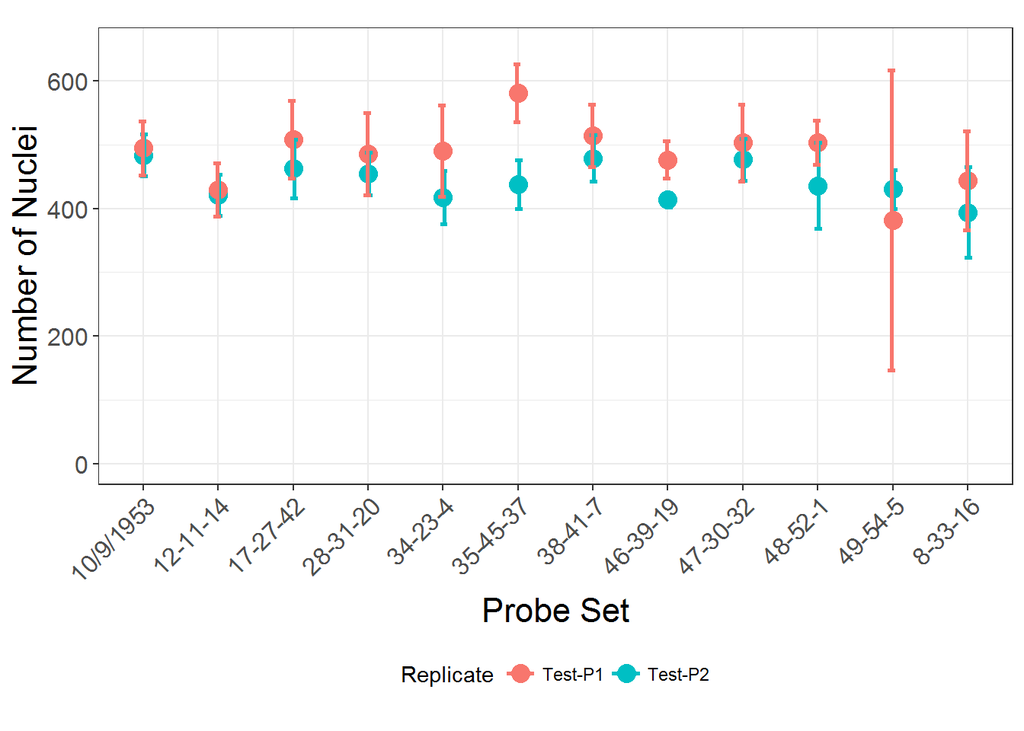

```r
plate1.dt <- plate.71.unetfh.R
plate2.dt <- plate.72.unetfh.R

names(plate1.dt) <- make.names(names(plate1.dt))
names(plate2.dt) <- make.names(names(plate2.dt))

plate2.dt$`Well.Position` <- trimws(plate2.dt$`Well.Position`)
plate1.dt$`Well.Position` <- trimws(plate1.dt$`Well.Position`)

plate1.dt$Number.of.Unique.Labels[plate1.dt$Number.of.Unique.Labels >6] <- 6
plate2.dt$Number.of.Unique.Labels[plate2.dt$Number.of.Unique.Labels >6] <- 6

plate1.dt.Summary <- plate1.dt %>% group_by(Well.Position,probe.set) %>%
  dplyr::summarise(n = n()) %>% dplyr::mutate(total = sum(n))
plate1.dt.Summary$Replicate <- 'Test-P1'


plate1.dt.msd <- ddply(plate1.dt.Summary , c("probe.set"), dplyr::summarise,
                         meanN = mean(total),
                         sdN   = sd(total)
)
plate1.dt.msd$Replicate <- 'Test-P1'

plate2.dt.Summary <- plate2.dt %>% group_by(Well.Position,probe.set) %>%
  dplyr::summarise(n = n()) %>% dplyr::mutate(total = sum(n))
plate2.dt.Summary$Replicate <- 'Test-P2'


plate2.dt.msd <- ddply(plate2.dt.Summary , c("probe.set"), dplyr::summarise,
                         meanN = mean(total),
                         sdN   = sd(total)
)
plate2.dt.msd$Replicate <- 'Test-P2'

ict7172.nuclei <- rbind(plate2.dt.msd, plate1.dt.msd)
nuc.gp2<- ggplot(ict7172.nuclei, aes(x=probe.set, y=meanN, color=Replicate))
nuc.gp2 <- nuc.gp2 +
    geom_point(size=4)+
    geom_errorbar(aes(ymin=meanN-sdN, ymax=meanN+sdN), width=.2,position=position_dodge(0.05), size=1.0)+
    ylab('Number of Nuclei') + coord_cartesian(ylim=c(0,650))+
    xlab('Probe Set')+
    theme_bw()+
    theme(axis.text=element_text(size=12), axis.title.y = element_text(size = rel(1.5)) , axis.title.x = element_text(size=rel(1.5)), axis.text.x = element_text(angle = 45, hjust = 1), aspect.ratio=0.5,legend.position="bottom", text=element_text(family="sans"))


print(nuc.gp2)
```

Let’s plot RFLearner’s of Plate TEST-P1-Green and Plate TEST-P2-Green

```r
ict7172.rf.green.gp2 <- gp2plate1vsplate2(plate.71.rf.G, plate.72.rf.G, platenames[1], platenames[2], 'Alexa488',4)
print(ict7172.rf.green.gp2)
```

```
## $msd
##     probe.set Number.of.Unique.Labels        mean          sd    meanN
## 1   10/9/1953                       0 0.008774513 0.005276793 483.2500
## 2   10/9/1953                       1 0.052222575 0.013176850 483.2500
## 3   10/9/1953                       2 0.220425890 0.032753200 483.2500
## 4   10/9/1953                       3 0.522796238 0.027809421 483.2500
## 5   10/9/1953                       4 0.115091219 0.028896338 483.2500
## 6   10/9/1953                       5 0.040784036 0.005848402 483.2500
## 7   10/9/1953                       6 0.039905529 0.002118342 483.2500
## 8    12-11-14                       0 0.031610536 0.005168352 420.5000
## 9    12-11-14                       1 0.112694509 0.011027846 420.5000
## 10   12-11-14                       2 0.250342880 0.022695827 420.5000
## 11   12-11-14                       3 0.363085432 0.022349850 420.5000
## 12   12-11-14                       4 0.149129323 0.022995865 420.5000
## 13   12-11-14                       5 0.044587001 0.014129562 420.5000
```

[output cut: 326 more lines]

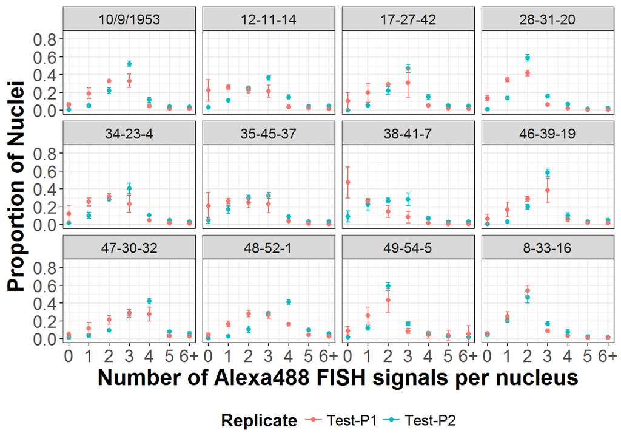

Let’s plot RFLearner’s of Plate TEST-P1-Red and Plate TEST-P2-Red

```r
ict7172.rf.red.gp2 <- gp2plate1vsplate2(plate.71.rf.R, plate.72.rf.R, platenames[1], platenames[2], 'ATTO565',4)
print(ict7172.rf.red.gp2)
```

```
## $msd
##     probe.set Number.of.Unique.Labels        mean           sd    meanN
## 1   10/9/1953                       0 0.004676313 0.0011075965 483.2500
## 2   10/9/1953                       1 0.033483654 0.0057874605 483.2500
## 3   10/9/1953                       2 0.193751703 0.0175483844 483.2500
## 4   10/9/1953                       3 0.657038028 0.0145982950 483.2500
## 5   10/9/1953                       4 0.058531556 0.0183600254 483.2500
## 6   10/9/1953                       5 0.019784551 0.0109739357 483.2500
## 7   10/9/1953                       6 0.032734194 0.0077531752 483.2500
## 8    12-11-14                       0 0.017241331 0.0049145968 420.5000
## 9    12-11-14                       1 0.064334991 0.0319506361 420.5000
## 10   12-11-14                       2 0.218003583 0.0337670308 420.5000
## 11   12-11-14                       3 0.386254574 0.0384502288 420.5000
## 12   12-11-14                       4 0.263734571 0.0198951228 420.5000
## 13   12-11-14                       5 0.021960857 0.0059257491 420.5000
```

[output cut: 322 more lines]

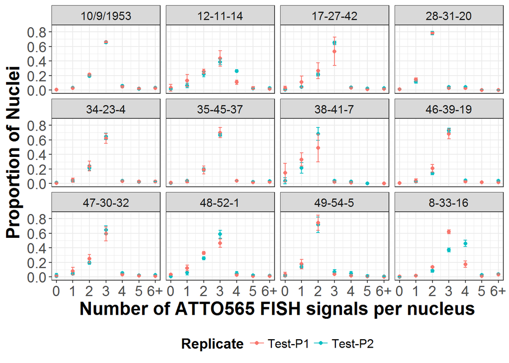

Let’s plot RFLearner’s of Plate TEST-P1-FarRed and Plate TEST-P2-Far-red

```r
ict7172.rf.farred.gp2 <- gp2plate1vsplate2(plate.71.rf.FR, plate.72.rf.FR, platenames[1], platenames[2], 'Cy5',4)
print(ict7172.rf.farred.gp2)
```

```
## $msd
##     probe.set Number.of.Unique.Labels        mean           sd    meanN
## 1   10/9/1953                       0 0.015765389 0.0075218914 483.2500
## 2   10/9/1953                       1 0.081959386 0.0141392819 483.2500
## 3   10/9/1953                       2 0.197222720 0.0295384157 483.2500
## 4   10/9/1953                       3 0.549389029 0.0309999335 483.2500
## 5   10/9/1953                       4 0.106298723 0.0077044305 483.2500
## 6   10/9/1953                       5 0.023776632 0.0069453020 483.2500
## 7   10/9/1953                       6 0.025588120 0.0089627023 483.2500
## 8    12-11-14                       0 0.059357656 0.0108507807 420.5000
## 9    12-11-14                       1 0.191107287 0.0059934820 420.5000
## 10   12-11-14                       2 0.268150988 0.0113040054 420.5000
## 11   12-11-14                       3 0.410623222 0.0067967747 420.5000
## 12   12-11-14                       4 0.041081052 0.0186462039 420.5000
## 13   12-11-14                       5 0.015325928 0.0039220945 420.5000
```

[output cut: 326 more lines]

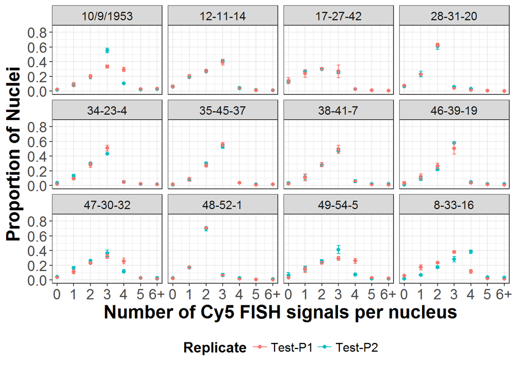

Let’s plot Unet-FH of Plate TEST-P1-Green and Plate TEST-P2-Green

```r
ict7172.unetfh.green.gp2 <- gp2plate1vsplate2(plate.71.unetfh.G, plate.72.unetfh.G, platenames[3], platenames[4], 'Alexa488',4)
print(ict7172.unetfh.green.gp2)
```

```
## $msd
##     probe.set Number.of.Unique.Labels        mean           sd    meanN
## 1   10/9/1953                       0 0.007308787 0.0029489684 483.2500
## 2   10/9/1953                       1 0.057157682 0.0130013688 483.2500
## 3   10/9/1953                       2 0.287984883 0.0181475824 483.2500
## 4   10/9/1953                       3 0.523558327 0.0379298566 483.2500
## 5   10/9/1953                       4 0.069158419 0.0171554686 483.2500
## 6   10/9/1953                       5 0.031855918 0.0087077385 483.2500
## 7   10/9/1953                       6 0.022975983 0.0067795880 483.2500
## 8    12-11-14                       0 0.016600927 0.0072577400 420.5000
## 9    12-11-14                       1 0.113135582 0.0187851516 420.5000
## 10   12-11-14                       2 0.317025827 0.0146458111 420.5000
## 11   12-11-14                       3 0.425499169 0.0201582946 420.5000
## 12   12-11-14                       4 0.080359212 0.0162841105 420.5000
## 13   12-11-14                       5 0.023518361 0.0058240522 420.5000
```

[output cut: 326 more lines]

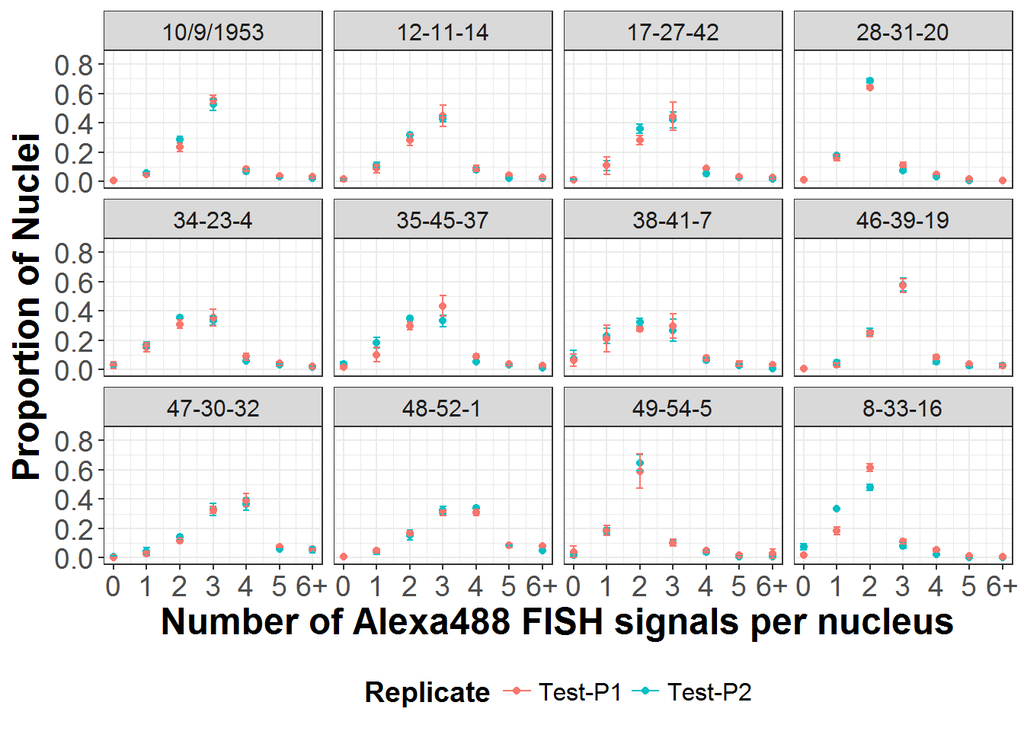

Let’s plot Unet-FH of Plate TEST-P1-Red and Plate TEST-P2-Red

```r
ict7172.unetfh.red.gp2 <- gp2plate1vsplate2(plate.71.unetfh.R, plate.72.unetfh.R, platenames[3], platenames[4], 'ATTO565',4)
print(ict7172.unetfh.red.gp2)
```

```
## $msd
##     probe.set Number.of.Unique.Labels        mean          sd    meanN
## 1   10/9/1953                       1 0.025598640 0.007704973 483.2500
## 2   10/9/1953                       2 0.200992673 0.012597215 483.2500
## 3   10/9/1953                       3 0.591643267 0.016362347 483.2500
## 4   10/9/1953                       4 0.112666595 0.008245004 483.2500
## 5   10/9/1953                       5 0.033966392 0.003759020 483.2500
## 6   10/9/1953                       6 0.035132432 0.002131422 483.2500
## 7    12-11-14                       1 0.017302156 0.002588655 420.5000
## 8    12-11-14                       2 0.144902388 0.026633728 420.5000
## 9    12-11-14                       3 0.455529023 0.036924728 420.5000
## 10   12-11-14                       4 0.281303335 0.034976535 420.5000
## 11   12-11-14                       5 0.045802511 0.017047552 420.5000
## 12   12-11-14                       6 0.055160587 0.009771625 420.5000
## 13   17-27-42                       1 0.021065230 0.008393125 462.0000
```

[output cut: 298 more lines]

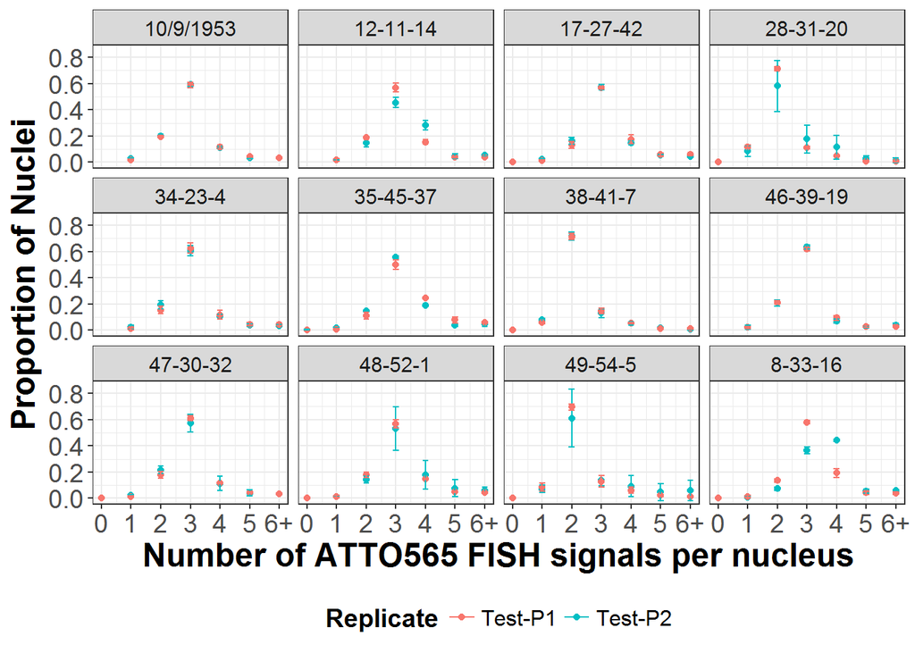

Let’s plot Unet-FH of Plate TEST-P1-FarRed and Plate TEST-P2-FarRed

```r
ict7172.unetfh.farred.gp2 <- gp2plate1vsplate2(plate.71.unetfh.FR, plate.72.unetfh.FR, platenames[3], platenames[4], 'Cy5',4)
print(ict7172.unetfh.farred.gp2)
```

```
## $msd
##     probe.set Number.of.Unique.Labels        mean          sd    meanN
## 1   10/9/1953                       1 0.021649820 0.008847013 483.2500
## 2   10/9/1953                       2 0.194442231 0.018163024 483.2500
## 3   10/9/1953                       3 0.533800226 0.035023079 483.2500
## 4   10/9/1953                       4 0.151221858 0.011299769 483.2500
## 5   10/9/1953                       5 0.050270346 0.023225452 483.2500
## 6   10/9/1953                       6 0.048615519 0.011126768 483.2500
## 7    12-11-14                       1 0.019976303 0.006441268 420.5000
## 8    12-11-14                       2 0.262630579 0.013035661 420.5000
## 9    12-11-14                       3 0.589460890 0.011312880 420.5000
## 10   12-11-14                       4 0.064691534 0.014315125 420.5000
## 11   12-11-14                       5 0.028840791 0.007764221 420.5000
## 12   12-11-14                       6 0.034399903 0.003869567 420.5000
## 13   17-27-42                       1 0.009600565 0.003304852 462.0000
```

[output cut: 278 more lines]

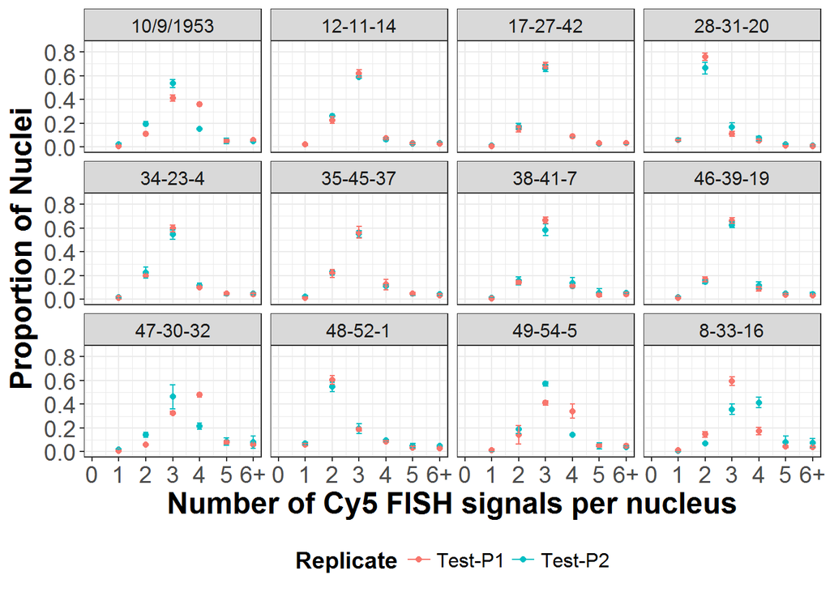